# Zeroes

Including or excluding onesies didn’t make much of a difference, so I wanted to confirm that it was the zeroes that were driving this weird pattern.

```r
# Import conflict settings.
source('../src/conflicted.R')

# Load some libraries.
library(tidyverse)
library(ggplot2)
library(raster)
library(sf)
library(landscapemetrics)
library(knitr)
library(kableExtra)
library(broom)
library(AICcmodavg)
library(modelr)

# Load in the processed data from last time.
data <- read_csv('../data/processed/landscape_metrics_zeroes.csv')

# Remove problematic TCR.
df <- data %>% filter(site != 'TCR')

# Keep only sites with occupancy data.
df <- df %>% drop_na(years.surveyed) #90

# Remove sites that are missing sufficient landscape data.
df <- df %>% filter_at(vars(contains('inside')), all_vars(. >=90))
```

How many zeroes are there, and what do they look like?

| site | name | years.surveyed | years.detect | years.no.detect |
| --- | --- | --- | --- | --- |
| BSL | Big Silver | 1 | 0 | 1 |
| BPT | Bohn Point | 1 | 0 | 1 |
| CCR | Center Creek | 4 | 0 | 4 |
| CHR | Cheakamus River | 1 | 0 | 1 |
| DKL | Duck Lake | 2 | 0 | 2 |
| ELA | Elaho | 2 | 0 | 2 |
| EMT | Elk Mountain | 2 | 0 | 2 |
| GIS | Goat Island | 3 | 0 | 3 |
| HKM | Heakamie | 1 | 0 | 1 |
| HSL | Hope Slide | 1 | 0 | 1 |

[output cut: 10 more lines]

First off, that’s 20 (!) sites that are zeroes. Some of these might be resolvable with a more precise data set… I think Red Tusk, for example, had actually been surveyed more than one year. Some of this may also be time-series issue… again, I think Red Tusk has been harvested, so these older occupancy data + more recent VRI data could explain why including zeroes gives me unusual results. But also very interesting that some of these sites have been surveyed for *years* and never been active, like Jarvis Creek at 5 (!) years. That supports the idea that at least some of these are either not NOGO territories or are so low quality that they bear no resemblance to “normal” NOGO territories.

I didn’t have ready-calculated HSI diversity, so I can add that (I think…). Start by bringing in the raster and prepping it.

```r
# Load HSI raster.
r.hsi <- raster('../data/processed/foraging_sc.tif')

# Define levels.
hsi.levels <- data.frame(ID=c(-10, -2, -1, 0, 1, 2, 3),
                         class.name=c('ocean', 'freshwater', 'river',
                                      'nil', 'low', 'moderate', 'high'))

# Add levels to raster.
levels(r.hsi) <- hsi.levels

# Assign crs to raster.
crs(r.hsi) <- CRS('+proj=utm +zone=10 +datum=NAD83 +units=m +no_defs')
```

Then get landscape sizes and sites set up.

```r
# Define landscape sizes.
landscape <- data.frame(
  size=c('PFA', 'breeding area', 'home range', 'maximum range'),
  area=c(60, 200, 3800, 15600)
)

# Convert area in hectares to radii in meters.
landscape <- landscape %>% mutate(radius=sqrt(area*10000/pi))

# Read in the data.
nests <- read_csv('../data/processed/sc_nests.csv')

# Calculate a centroid for each site, and keep only ones with a quality index.
centroids <- nests %>% group_by(site) %>%
  mutate(mean.x=mean(xcoord), mean.y=mean(ycoord)) %>%
  distinct(site, name, mean.x, mean.y)

sites <- semi_join(centroids, data, by=c('site', 'name')) %>%
  rename(xcoord=mean.x, ycoord=mean.y)

# Make it a spatial object for later.
sites.sf <- sites %>%
  st_as_sf(coords=c('xcoord', 'ycoord')) %>%
  st_set_crs('+proj=utm +zone=10 +datum=WGS84 +units=m +no_defs') %>%
  st_as_sf()

# Also make a list of site names for later.
site.names <- sites.sf$site
```

Then do the actual calculations.

```r
# Make a list of metrics to calculate.
hsi.metrics <- c('lsm_l_sidi')

# Make a function to do the calculations and formatting.
calc.hsi.metrics <- function(x) {
  sample_lsm(r.hsi, y=sites.sf, size=x, plot_id=site.names, shape='circle',
             what=hsi.metrics) %>%
    left_join(hsi.levels, by=c('class'='ID')) %>%
    mutate(class.name=ifelse(is.na(class.name), metric, class.name)) %>%
    select(-class, -metric, -level) %>%
    pivot_wider(names_from=class.name, values_from=value) %>%
    mutate(radius=x) %>%
    rename(hsi.inside=percentage_inside)
}

# Run the function for each sample size.
hsi.landscape.metrics <- map_df(landscape$radius, calc.hsi.metrics)
```

```
The 'perecentage_inside' is below 90% for at least one buffer.The 'perecentage_inside' is below 90% for at least one buffer.
```

```r
# Do some cleanup
hsi.landscape.metrics <- hsi.landscape.metrics %>%
  select(radius, hsi.inside, nest=plot_id, hsi.diversity=sidi)

hsi.landscape.metrics <- select(landscape, radius, size) %>% right_join(hsi.landscape.metrics, by=c('radius'))

# Join to data frame.
df <- left_join(df, hsi.landscape.metrics, by=c('site'='nest', 'size', 'radius', 'hsi.inside'))

# Filter out any sites without sufficient landscape coverage.
df <- df %>% filter_at(vars(contains('inside')), all_vars(. >=90))
```

# The models

```r
# Proportion suitable
proportion.suitable.model <- function(df) {
  glm(cbind(years.detect, years.no.detect) ~ proportion.suitable, data=df, family=binomial(logit))
}

# Proportion suitable + HSI diversity
suitable.diversity.model <- function(df) {
  glm(cbind(years.detect, years.no.detect) ~ proportion.suitable + hsi.diversity, data=df, family=binomial(logit))
}

# Proportion suitable + suitable edge density
suitable.edge.density.model <- function(df) {
  glm(cbind(years.detect, years.no.detect) ~ proportion.suitable + suitable.edge.density, data=df, family=binomial(logit))
}

# Proportion suitable + HSI diversity + suitable edge density
suitable.sink.model <- function(df) {
  glm(cbind(years.detect, years.no.detect) ~ proportion.suitable +
        suitable.edge.density + hsi.diversity, data=df, family=binomial(logit))
}

# Proportion mature forest
proportion.mature.model <- function(df) {
  glm(cbind(years.detect, years.no.detect) ~ proportion.cover.mature, data=df, family=binomial(logit))
}

# Proportion mature + landcover diversity
mature.diversity.model <- function(df) {
  glm(cbind(years.detect, years.no.detect) ~ proportion.cover.mature + cover.diversity, data=df, family=binomial(logit))
}

# Proportion mature + gap edge density
mature.edge.density.model <- function(df) {
  glm(cbind(years.detect, years.no.detect) ~ proportion.cover.mature + gap.edge.density, data=df, family=binomial(logit))
}

# Proportion mature + gap edge density + landcover diversity
mature.sink.model <- function(df) {
  glm(cbind(years.detect, years.no.detect) ~ proportion.cover.mature +
        gap.edge.density + cover.diversity, data=df, family=binomial(logit))
}

# Null
null.model <- function(df) {
  glm(cbind(years.detect, years.no.detect) ~ 1, data=df, family=binomial(logit))
}
```

Then nest the data frame for ease of coding and apply each function to generate a disturbingly large number of models really fast.

```r
# Nest the data frame.
nf <- df %>% group_by(size) %>% nest()

# Apply the functions.
nf <- nf %>%
  mutate(
    m.proportion.suitable=map(data, proportion.suitable.model),
    m.suitable.diversity=map(data, suitable.diversity.model),
    m.suitable.edge.density=map(data, suitable.edge.density.model),
    m.suitable.sink=map(data, suitable.sink.model),
    m.proportion.mature=map(data, proportion.mature.model),
    m.mature.diversity=map(data, mature.diversity.model),
    m.mature.edge.density=map(data, mature.edge.density.model),
    m.mature.sink=map(data, mature.sink.model),
    m.null=map(data, null.model)
         )
```

Let’s see if there’s any difference in the big list of models.

```r
all.models <- nf %>% pivot_longer(-c(size, data), names_to='modname', values_to='model') %>%
  mutate(name=paste(size, modname))

aictab(all.models$model, modnames=all.models$name) %>%
  kable() %>% kable_styling(bootstrap_options=c('striped'))
```

|  | Modnames | K | AICc | Delta_AICc | ModelLik | AICcWt | LL | Cum.Wt |
| --- | --- | --- | --- | --- | --- | --- | --- | --- |
| 11 | breeding area m.suitable.diversity | 3 | 170.4396 | 0.000000 | 1.0000000 | 0.5243927 | -82.04331 | 0.5243927 |
| 13 | breeding area m.suitable.sink | 4 | 172.4820 | 2.042439 | 0.3601554 | 0.1888629 | -81.94249 | 0.7132556 |
| 1 | PFA m.proportion.suitable | 2 | 175.5904 | 5.150819 | 0.0761226 | 0.0399182 | -85.70823 | 0.7531737 |
| 2 | PFA m.suitable.diversity | 3 | 175.9297 | 5.490175 | 0.0642427 | 0.0336884 | -84.78840 | 0.7868621 |
| 16 | breeding area m.mature.edge.density | 3 | 176.2359 | 5.796381 | 0.0551229 | 0.0289060 | -84.94150 | 0.8157682 |
| 35 | maximum range m.mature.sink | 4 | 176.6375 | 6.197963 | 0.0450951 | 0.0236475 | -84.01107 | 0.8394157 |
| 34 | maximum range m.mature.edge.density | 3 | 176.6641 | 6.224528 | 0.0445001 | 0.0233355 | -85.15023 | 0.8627512 |
| 7 | PFA m.mature.edge.density | 3 | 177.5006 | 7.061065 | 0.0292893 | 0.0153591 | -85.57384 | 0.8781103 |
| 3 | PFA m.suitable.edge.density | 3 | 177.6871 | 7.247493 | 0.0266825 | 0.0139921 | -85.66706 | 0.8921025 |
| 4 | PFA m.suitable.sink | 4 | 177.9820 | 7.542394 | 0.0230245 | 0.0120739 | -84.69247 | 0.9041763 |
| 17 | breeding area m.mature.sink | 4 | 178.4749 | 8.035326 | 0.0179950 | 0.0094364 | -84.93893 | 0.9136128 |
| 10 | breeding area m.proportion.suitable | 2 | 178.4951 | 8.055566 | 0.0178138 | 0.0093414 | -87.16061 | 0.9229542 |
| 36 | maximum range m.null | 1 | 178.5391 | 8.099542 | 0.0174264 | 0.0091383 | -88.24014 | 0.9320924 |
| 32 | maximum range m.proportion.mature | 2 | 178.6594 | 8.219818 | 0.0164093 | 0.0086049 | -87.24014 | 0.9406973 |
| 26 | home range m.mature.sink | 4 | 178.7814 | 8.341837 | 0.0154381 | 0.0080956 | -85.08767 | 0.9487930 |
| 33 | maximum range m.mature.diversity | 3 | 179.4648 | 9.025255 | 0.0109696 | 0.0057524 | -86.55059 | 0.9545453 |
| 20 | home range m.suitable.diversity | 3 | 179.5833 | 9.143778 | 0.0103384 | 0.0054214 | -86.61256 | 0.9599667 |
| 8 | PFA m.mature.sink | 4 | 179.6936 | 9.253993 | 0.0097841 | 0.0051307 | -85.54827 | 0.9650974 |
| 27 | home range m.null | 1 | 179.8091 | 9.369525 | 0.0092349 | 0.0048427 | -88.87556 | 0.9699402 |
| 12 | breeding area m.suitable.edge.density | 3 | 180.1510 | 9.711490 | 0.0077835 | 0.0040816 | -86.89905 | 0.9740218 |
| 25 | home range m.mature.edge.density | 3 | 180.2831 | 9.843515 | 0.0072863 | 0.0038209 | -86.96243 | 0.9778427 |
| 19 | home range m.proportion.suitable | 2 | 180.4571 | 10.017580 | 0.0066790 | 0.0035024 | -88.14033 | 0.9813451 |
| 28 | maximum range m.proportion.suitable | 2 | 180.5214 | 10.081825 | 0.0064678 | 0.0033917 | -88.17114 | 0.9847368 |
| 24 | home range m.mature.diversity | 3 | 180.7009 | 10.261298 | 0.0059127 | 0.0031006 | -87.17132 | 0.9878374 |
| 23 | home range m.proportion.mature | 2 | 180.9794 | 10.539793 | 0.0051441 | 0.0026976 | -88.40144 | 0.9905349 |
| 22 | home range m.suitable.sink | 4 | 181.8280 | 11.388416 | 0.0033654 | 0.0017648 | -86.61096 | 0.9922997 |
| 29 | maximum range m.suitable.diversity | 3 | 182.1413 | 11.701715 | 0.0028774 | 0.0015089 | -87.88882 | 0.9938086 |
| 30 | maximum range m.suitable.edge.density | 3 | 182.4118 | 11.972195 | 0.0025135 | 0.0013180 | -88.02406 | 0.9951266 |
| 21 | home range m.suitable.edge.density | 3 | 182.6240 | 12.184404 | 0.0022604 | 0.0011854 | -88.13288 | 0.9963120 |
| 5 | PFA m.proportion.mature | 2 | 183.1932 | 12.753682 | 0.0017005 | 0.0008917 | -89.50966 | 0.9972037 |
| 31 | maximum range m.suitable.sink | 4 | 184.0019 | 13.562384 | 0.0011349 | 0.0005951 | -87.69328 | 0.9977989 |
| 6 | PFA m.mature.diversity | 3 | 184.2070 | 13.767391 | 0.0010244 | 0.0005372 | -88.92700 | 0.9983360 |
| 9 | PFA m.null | 1 | 184.2986 | 13.859011 | 0.0009785 | 0.0005131 | -91.12071 | 0.9988491 |
| 18 | breeding area m.null | 1 | 184.2986 | 13.859011 | 0.0009785 | 0.0005131 | -91.12071 | 0.9993622 |
| 14 | breeding area m.proportion.mature | 2 | 184.5828 | 14.143224 | 0.0008489 | 0.0004451 | -90.20444 | 0.9998074 |
| 15 | breeding area m.mature.diversity | 3 | 186.2582 | 15.818621 | 0.0003673 | 0.0001926 | -89.95262 | 1.0000000 |

Let’s break it down by size.

```r
pfa.models <- nf %>% filter(size == 'PFA') %>%
  pivot_longer(-c(size, data), names_to='modname', values_to='model')

ba.models <- nf %>% filter(size == 'breeding area') %>%
  pivot_longer(-c(size, data), names_to='modname', values_to='model')

hr.models <- nf %>% filter(size == 'home range') %>%
  pivot_longer(-c(size, data), names_to='modname', values_to='model')

mr.models <- nf %>% filter(size == 'maximum range') %>%
  pivot_longer(-c(size, data), names_to='modname', values_to='model')
```

## PFA

```r
aictab(pfa.models$model, modnames=pfa.models$modname) %>%
  kable() %>% kable_styling(bootstrap_options=c('striped'))
```

|  | Modnames | K | AICc | Delta_AICc | ModelLik | AICcWt | LL | Cum.Wt |
| --- | --- | --- | --- | --- | --- | --- | --- | --- |
| 1 | m.proportion.suitable | 2 | 175.5904 | 0.000000 | 1.0000000 | 0.3269184 | -85.70823 | 0.3269184 |
| 2 | m.suitable.diversity | 3 | 175.9297 | 0.339356 | 0.8439365 | 0.2758984 | -84.78840 | 0.6028168 |
| 7 | m.mature.edge.density | 3 | 177.5006 | 1.910246 | 0.3847648 | 0.1257867 | -85.57384 | 0.7286034 |
| 3 | m.suitable.edge.density | 3 | 177.6871 | 2.096674 | 0.3505202 | 0.1145915 | -85.66706 | 0.8431950 |
| 4 | m.suitable.sink | 4 | 177.9820 | 2.391575 | 0.3024656 | 0.0988816 | -84.69247 | 0.9420765 |
| 8 | m.mature.sink | 4 | 179.6936 | 4.103174 | 0.1285308 | 0.0420191 | -85.54827 | 0.9840956 |
| 5 | m.proportion.mature | 2 | 183.1932 | 7.602863 | 0.0223388 | 0.0073030 | -89.50966 | 0.9913986 |
| 6 | m.mature.diversity | 3 | 184.2070 | 8.616572 | 0.0134566 | 0.0043992 | -88.92700 | 0.9957978 |
| 9 | m.null | 1 | 184.2986 | 8.708192 | 0.0128541 | 0.0042022 | -91.12071 | 1.0000000 |

So here *all* the models perform better than the null, and HSI-based models generally do better than the VRI-based models.

### Top model

We can visualize the top model. Maybe.

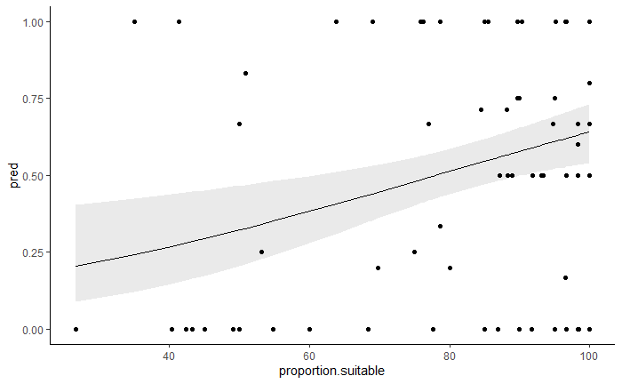

```r
summary(pfa.top.model)
```

```
Call:
glm(formula = cbind(years.detect, years.no.detect) ~ proportion.suitable,
    family = binomial(logit), data = pfa.data)

Deviance Residuals:
    Min       1Q   Median       3Q      Max
-2.2845  -1.1590  -0.2809   0.9425   2.6883

Coefficients:
                    Estimate Std. Error z value Pr(>|z|)
(Intercept)         -2.06840    0.69912  -2.959  0.00309 **
proportion.suitable  0.02650    0.00834   3.177  0.00149 **
---
Signif. codes:  0 ‘***’ 0.001 ‘**’ 0.01 ‘*’ 0.05 ‘.’ 0.1 ‘ ’ 1

(Dispersion parameter for binomial family taken to be 1)

    Null deviance: 125.29  on 71  degrees of freedom
Residual deviance: 114.47  on 70  degrees of freedom
AIC: 175.42

Number of Fisher Scoring iterations: 3
```

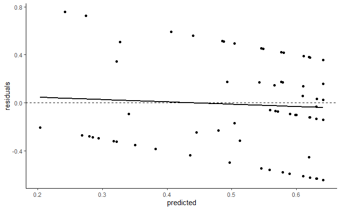

```r
# Look at some diagnostics.
data.frame(predicted=predict(pfa.top.model, type='response'),
           residuals=residuals(pfa.top.model, type='response')) %>%
  ggplot(aes(x=predicted, y=residuals)) +
  geom_point() +
  geom_hline(yintercept=0, linetype='dashed') +
  geom_smooth(method='lm', se=FALSE, color='black') +
  theme_classic()
```

Um, ok, those residuals are pretty wonky: that’s a very strong pattern.

### All models

```r
pfa.models %>% mutate(glance=map(model, glance)) %>%
  unnest(glance) %>% ungroup() %>%
  select(!c(size, data, model))
```

| modname | null.deviance | df.null | logLik | AIC | BIC | deviance | df.residual |
| --- | --- | --- | --- | --- | --- | --- | --- |
| m.proportion.suitable | 125.2944 | 71 | -85.70823 | 175.4165 | 179.9698 | 114.4694 | 70 |
| m.suitable.diversity | 125.2944 | 71 | -84.78840 | 175.5768 | 182.4068 | 112.6297 | 69 |
| m.suitable.edge.density | 125.2944 | 71 | -85.66706 | 177.3341 | 184.1641 | 114.3871 | 69 |
| m.suitable.sink | 125.2944 | 71 | -84.69247 | 177.3849 | 186.4916 | 112.4379 | 68 |
| m.proportion.mature | 125.2944 | 71 | -89.50966 | 183.0193 | 187.5727 | 122.0723 | 70 |
| m.mature.diversity | 125.2944 | 71 | -88.92700 | 183.8540 | 190.6840 | 120.9070 | 69 |
| m.mature.edge.density | 125.2944 | 71 | -85.57384 | 177.1477 | 183.9777 | 114.2006 | 69 |
| m.mature.sink | 125.2944 | 71 | -85.54827 | 179.0965 | 188.2032 | 114.1495 | 68 |
| m.null | 125.2944 | 71 | -91.12071 | 184.2414 | 186.5181 | 125.2944 | 71 |

```r
pfa.models %>% mutate(tidy=map(model, tidy)) %>%
  unnest(tidy) %>% ungroup() %>%
  select(!c(size, data, model)) %>%
  filter(term != '(Intercept)')
```

| modname | term | estimate | std.error | statistic | p.value |
| --- | --- | --- | --- | --- | --- |
| m.proportion.suitable | proportion.suitable | 0.026497431 | 0.008339843 | 3.1772097 | 0.0014869946 |
| m.suitable.diversity | proportion.suitable | 0.034448209 | 0.010409103 | 3.3094313 | 0.0009348572 |
| m.suitable.diversity | hsi.diversity | 1.198786352 | 0.890043832 | 1.3468846 | 0.1780173944 |
| m.suitable.edge.density | proportion.suitable | 0.022761128 | 0.015400056 | 1.4779899 | 0.1394104752 |
| m.suitable.edge.density | suitable.edge.density | -0.004433471 | 0.015454570 | -0.2868712 | 0.7742109425 |
| m.suitable.sink | proportion.suitable | 0.028938793 | 0.016223146 | 1.7837966 | 0.0744567230 |
| m.suitable.sink | suitable.edge.density | -0.006847322 | 0.015645097 | -0.4376657 | 0.6616286433 |
| m.suitable.sink | hsi.diversity | 1.242640633 | 0.896870167 | 1.3855301 | 0.1658904283 |
| m.proportion.mature | proportion.cover.mature | 0.008389038 | 0.004713756 | 1.7796929 | 0.0751262312 |
| m.mature.diversity | proportion.cover.mature | 0.006745529 | 0.004936659 | 1.3664160 | 0.1718084349 |

[output cut: 6 more lines]

## Breeding area

```r
aictab(ba.models$model, modnames=ba.models$modname) %>%
  kable() %>% kable_styling(bootstrap_options=c('striped'))
```

|  | Modnames | K | AICc | Delta_AICc | ModelLik | AICcWt | LL | Cum.Wt |
| --- | --- | --- | --- | --- | --- | --- | --- | --- |
| 2 | m.suitable.diversity | 3 | 170.4396 | 0.000000 | 1.0000000 | 0.6844321 | -82.04331 | 0.6844321 |
| 4 | m.suitable.sink | 4 | 172.4820 | 2.042439 | 0.3601554 | 0.2465020 | -81.94249 | 0.9309341 |
| 7 | m.mature.edge.density | 3 | 176.2359 | 5.796381 | 0.0551229 | 0.0377279 | -84.94150 | 0.9686619 |
| 8 | m.mature.sink | 4 | 178.4749 | 8.035326 | 0.0179950 | 0.0123163 | -84.93893 | 0.9809783 |
| 1 | m.proportion.suitable | 2 | 178.4951 | 8.055566 | 0.0178138 | 0.0121923 | -87.16061 | 0.9931706 |
| 3 | m.suitable.edge.density | 3 | 180.1510 | 9.711490 | 0.0077835 | 0.0053273 | -86.89905 | 0.9984979 |
| 9 | m.null | 1 | 184.2986 | 13.859011 | 0.0009785 | 0.0006697 | -91.12071 | 0.9991676 |
| 5 | m.proportion.mature | 2 | 184.5828 | 14.143224 | 0.0008489 | 0.0005810 | -90.20444 | 0.9997486 |
| 6 | m.mature.diversity | 3 | 186.2582 | 15.818621 | 0.0003673 | 0.0002514 | -89.95262 | 1.0000000 |

Again, null down towards the bottom and HSI-based models generally better than VRI-based models.

### Top model

We can also visualize the top model for the breeding area.

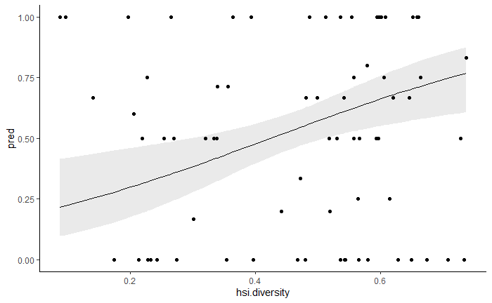

```r
summary(ba.top.model)
```

```
Call:
glm(formula = cbind(years.detect, years.no.detect) ~ proportion.suitable +
    hsi.diversity, family = binomial(logit), data = ba.data)

Deviance Residuals:
    Min       1Q   Median       3Q      Max
-2.2724  -1.0593  -0.2405   1.1119   2.9692

Coefficients:
                    Estimate Std. Error z value Pr(>|z|)
(Intercept)         -5.88006    1.51884  -3.871 0.000108 ***
proportion.suitable  0.05561    0.01413   3.935 8.31e-05 ***
hsi.diversity        3.81977    1.22821   3.110 0.001871 **
---
Signif. codes:  0 ‘***’ 0.001 ‘**’ 0.01 ‘*’ 0.05 ‘.’ 0.1 ‘ ’ 1

(Dispersion parameter for binomial family taken to be 1)

    Null deviance: 125.29  on 71  degrees of freedom
Residual deviance: 107.14  on 69  degrees of freedom
AIC: 170.09

Number of Fisher Scoring iterations: 4
```

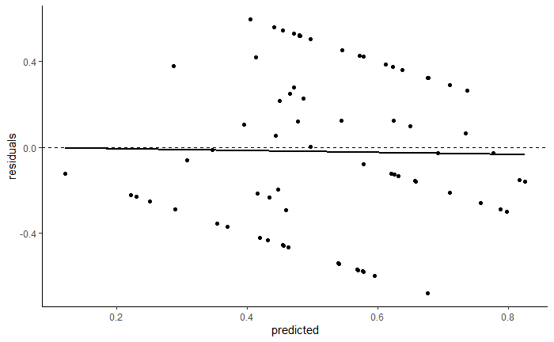

```r
# Look at some diagnostics.
data.frame(predicted=predict(ba.top.model, type='response'),
           residuals=residuals(ba.top.model, type='response')) %>%
  ggplot(aes(x=predicted, y=residuals)) +
  geom_point() +
  geom_hline(yintercept=0, linetype='dashed') +
  geom_smooth(method='lm', se=FALSE, color='black') +
  theme_classic()
```

Again, residuals are worse.

### All models

```r
ba.models %>% mutate(glance=map(model, glance)) %>%
  unnest(glance) %>% ungroup() %>%
  select(!c(size, data, model))
```

| modname | null.deviance | df.null | logLik | AIC | BIC | deviance | df.residual |
| --- | --- | --- | --- | --- | --- | --- | --- |
| m.proportion.suitable | 125.2944 | 71 | -87.16061 | 178.3212 | 182.8745 | 117.3742 | 70 |
| m.suitable.diversity | 125.2944 | 71 | -82.04331 | 170.0866 | 176.9166 | 107.1396 | 69 |
| m.suitable.edge.density | 125.2944 | 71 | -86.89905 | 179.7981 | 186.6281 | 116.8510 | 69 |
| m.suitable.sink | 125.2944 | 71 | -81.94249 | 171.8850 | 180.9916 | 106.9379 | 68 |
| m.proportion.mature | 125.2944 | 71 | -90.20444 | 184.4089 | 188.9622 | 123.4618 | 70 |
| m.mature.diversity | 125.2944 | 71 | -89.95262 | 185.9052 | 192.7352 | 122.9582 | 69 |
| m.mature.edge.density | 125.2944 | 71 | -84.94150 | 175.8830 | 182.7130 | 112.9359 | 69 |
| m.mature.sink | 125.2944 | 71 | -84.93893 | 177.8779 | 186.9845 | 112.9308 | 68 |
| m.null | 125.2944 | 71 | -91.12071 | 184.2414 | 186.5181 | 125.2944 | 71 |

```r
ba.models %>% mutate(tidy=map(model, tidy)) %>%
  unnest(tidy) %>% ungroup() %>%
  select(!c(size, data, model)) %>%
  filter(term != '(Intercept)')
```

| modname | term | estimate | std.error | statistic | p.value |
| --- | --- | --- | --- | --- | --- |
| m.proportion.suitable | proportion.suitable | 0.027264353 | 0.009940858 | 2.74265583 | 6.094453e-03 |
| m.suitable.diversity | proportion.suitable | 0.055609387 | 0.014131481 | 3.93514208 | 8.314749e-05 |
| m.suitable.diversity | hsi.diversity | 3.819774215 | 1.228206557 | 3.11004219 | 1.870606e-03 |
| m.suitable.edge.density | proportion.suitable | 0.038750163 | 0.018928228 | 2.04721558 | 4.063692e-02 |
| m.suitable.edge.density | suitable.edge.density | 0.014172368 | 0.019659489 | 0.72089199 | 4.709760e-01 |
| m.suitable.sink | proportion.suitable | 0.062816956 | 0.021578957 | 2.91102842 | 3.602412e-03 |
| m.suitable.sink | suitable.edge.density | 0.009230717 | 0.020583694 | 0.44844803 | 6.538299e-01 |
| m.suitable.sink | hsi.diversity | 3.775055548 | 1.232311425 | 3.06339410 | 2.188416e-03 |
| m.proportion.mature | proportion.cover.mature | 0.007163567 | 0.005316092 | 1.34752500 | 1.778112e-01 |
| m.mature.diversity | proportion.cover.mature | 0.006081301 | 0.005527371 | 1.10021583 | 2.712381e-01 |

[output cut: 6 more lines]

## Home range

```r
aictab(hr.models$model, modnames=hr.models$modname) %>%
  kable() %>% kable_styling(bootstrap_options=c('striped'))
```

|  | Modnames | K | AICc | Delta_AICc | ModelLik | AICcWt | LL | Cum.Wt |
| --- | --- | --- | --- | --- | --- | --- | --- | --- |
| 8 | m.mature.sink | 4 | 178.7814 | 0.0000000 | 1.0000000 | 0.2351236 | -85.08767 | 0.2351236 |
| 2 | m.suitable.diversity | 3 | 179.5833 | 0.8019416 | 0.6696696 | 0.1574551 | -86.61256 | 0.3925788 |
| 9 | m.null | 1 | 179.8091 | 1.0276884 | 0.5981916 | 0.1406490 | -88.87556 | 0.5332277 |
| 7 | m.mature.edge.density | 3 | 180.2831 | 1.5016780 | 0.4719704 | 0.1109714 | -86.96243 | 0.6441991 |
| 1 | m.proportion.suitable | 2 | 180.4571 | 1.6757439 | 0.4326302 | 0.1017216 | -88.14033 | 0.7459207 |
| 6 | m.mature.diversity | 3 | 180.7009 | 1.9194610 | 0.3829961 | 0.0900514 | -87.17132 | 0.8359721 |
| 5 | m.proportion.mature | 2 | 180.9794 | 2.1979560 | 0.3332114 | 0.0783459 | -88.40144 | 0.9143180 |
| 4 | m.suitable.sink | 4 | 181.8280 | 3.0465790 | 0.2179936 | 0.0512554 | -86.61096 | 0.9655735 |
| 3 | m.suitable.edge.density | 3 | 182.6240 | 3.8425672 | 0.1464189 | 0.0344265 | -88.13288 | 1.0000000 |

### Top model

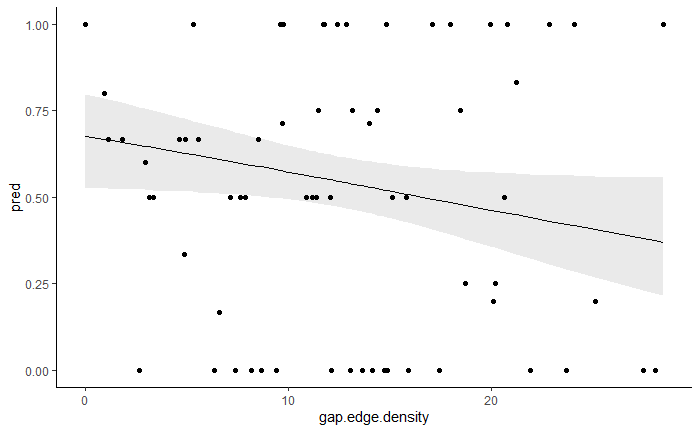

```r
summary(hr.top.model)
```

```
Call:
glm(formula = cbind(years.detect, years.no.detect) ~ proportion.cover.mature +
    gap.edge.density + cover.diversity, family = binomial(logit),
    data = hr.data)

Deviance Residuals:
     Min        1Q    Median        3Q       Max
-2.26896  -1.19142  -0.08727   1.07213   2.51586

Coefficients:
                         Estimate Std. Error z value Pr(>|z|)
(Intercept)             -1.378034   0.995964  -1.384   0.1665
proportion.cover.mature  0.009682   0.008241   1.175   0.2401
gap.edge.density        -0.044628   0.022108  -2.019   0.0435 *
cover.diversity          2.341545   1.281406   1.827   0.0677 .
---
Signif. codes:  0 ‘***’ 0.001 ‘**’ 0.01 ‘*’ 0.05 ‘.’ 0.1 ‘ ’ 1

(Dispersion parameter for binomial family taken to be 1)

    Null deviance: 120.80  on 70  degrees of freedom
Residual deviance: 113.23  on 67  degrees of freedom
AIC: 178.18

Number of Fisher Scoring iterations: 4
```

### All models

```r
hr.models %>% mutate(tidy=map(model, tidy)) %>%
  unnest(tidy) %>% ungroup() %>%
  select(!c(size, data, model)) %>%
  filter(term != '(Intercept)')
```

| modname | term | estimate | std.error | statistic | p.value |
| --- | --- | --- | --- | --- | --- |
| m.proportion.suitable | proportion.suitable | -0.012181651 | 0.010083511 | -1.20807632 | 0.22701791 |
| m.suitable.diversity | proportion.suitable | -0.025345819 | 0.012840173 | -1.97394683 | 0.04838779 |
| m.suitable.diversity | hsi.diversity | -5.278627062 | 3.054876024 | -1.72793495 | 0.08399989 |
| m.suitable.edge.density | proportion.suitable | -0.012140053 | 0.010087446 | -1.20348136 | 0.22879010 |
| m.suitable.edge.density | suitable.edge.density | 0.002467708 | 0.020202757 | 0.12214707 | 0.90278254 |
| m.suitable.sink | proportion.suitable | -0.025307701 | 0.012855323 | -1.96865531 | 0.04899269 |
| m.suitable.sink | suitable.edge.density | 0.001159051 | 0.020441799 | 0.05670003 | 0.95478415 |
| m.suitable.sink | hsi.diversity | -5.271647624 | 3.056863028 | -1.72452857 | 0.08461247 |
| m.proportion.mature | proportion.cover.mature | 0.007595672 | 0.007826771 | 0.97047325 | 0.33181065 |
| m.mature.diversity | proportion.cover.mature | 0.007784193 | 0.008049216 | 0.96707466 | 0.33350671 |

[output cut: 6 more lines]

## Maximum range

```r
aictab(mr.models$model, modnames=mr.models$modname) %>%
  kable() %>% kable_styling(bootstrap_options=c('striped'))
```

|  | Modnames | K | AICc | Delta_AICc | ModelLik | AICcWt | LL | Cum.Wt |
| --- | --- | --- | --- | --- | --- | --- | --- | --- |
| 8 | m.mature.sink | 4 | 176.6375 | 0.000000 | 1.0000000 | 0.3059493 | -84.01107 | 0.3059493 |
| 7 | m.mature.edge.density | 3 | 176.6641 | 0.026565 | 0.9868053 | 0.3019124 | -85.15023 | 0.6078616 |
| 9 | m.null | 1 | 178.5391 | 1.901579 | 0.3864357 | 0.1182297 | -88.24014 | 0.7260913 |
| 5 | m.proportion.mature | 2 | 178.6594 | 2.021855 | 0.3638813 | 0.1113292 | -87.24014 | 0.8374205 |
| 6 | m.mature.diversity | 3 | 179.4648 | 2.827292 | 0.2432548 | 0.0744236 | -86.55059 | 0.9118442 |
| 1 | m.proportion.suitable | 2 | 180.5214 | 3.883862 | 0.1434267 | 0.0438813 | -88.17114 | 0.9557255 |
| 2 | m.suitable.diversity | 3 | 182.1413 | 5.503752 | 0.0638080 | 0.0195220 | -87.88882 | 0.9752475 |
| 3 | m.suitable.edge.density | 3 | 182.4118 | 5.774233 | 0.0557367 | 0.0170526 | -88.02406 | 0.9923001 |
| 4 | m.suitable.sink | 4 | 184.0019 | 7.364421 | 0.0251673 | 0.0076999 | -87.69328 | 1.0000000 |

### Top model

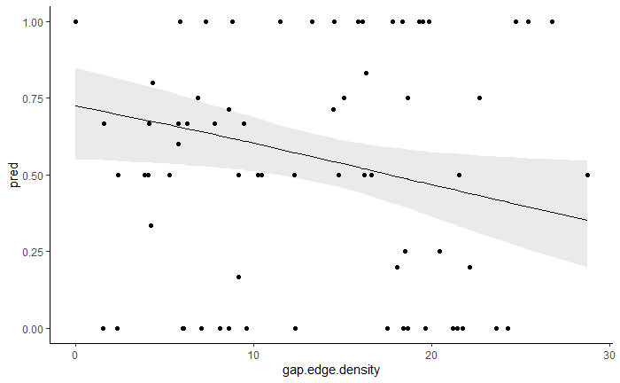

```r
summary(hr.top.model)
```

```
Call:
glm(formula = cbind(years.detect, years.no.detect) ~ proportion.cover.mature +
    gap.edge.density + cover.diversity, family = binomial(logit),
    data = hr.data)

Deviance Residuals:
     Min        1Q    Median        3Q       Max
-2.26896  -1.19142  -0.08727   1.07213   2.51586

Coefficients:
                         Estimate Std. Error z value Pr(>|z|)
(Intercept)             -1.378034   0.995964  -1.384   0.1665
proportion.cover.mature  0.009682   0.008241   1.175   0.2401
gap.edge.density        -0.044628   0.022108  -2.019   0.0435 *
cover.diversity          2.341545   1.281406   1.827   0.0677 .
---
Signif. codes:  0 ‘***’ 0.001 ‘**’ 0.01 ‘*’ 0.05 ‘.’ 0.1 ‘ ’ 1

(Dispersion parameter for binomial family taken to be 1)

    Null deviance: 120.80  on 70  degrees of freedom
Residual deviance: 113.23  on 67  degrees of freedom
AIC: 178.18

Number of Fisher Scoring iterations: 4
```

### All models

```r
mr.models %>% mutate(glance=map(model, glance)) %>%
  unnest(glance) %>% ungroup() %>%
  select(!c(size, data, model))
```

| modname | null.deviance | df.null | logLik | AIC | BIC | deviance | df.residual |
| --- | --- | --- | --- | --- | --- | --- | --- |
| m.proportion.suitable | 119.5332 | 69 | -88.17114 | 180.3423 | 184.8393 | 119.3952 | 68 |
| m.suitable.diversity | 119.5332 | 69 | -87.88882 | 181.7776 | 188.5231 | 118.8306 | 67 |
| m.suitable.edge.density | 119.5332 | 69 | -88.02406 | 182.0481 | 188.7936 | 119.1011 | 67 |
| m.suitable.sink | 119.5332 | 69 | -87.69328 | 183.3866 | 192.3805 | 118.4395 | 66 |
| m.proportion.mature | 119.5332 | 69 | -87.24014 | 178.4803 | 182.9773 | 117.5332 | 68 |
| m.mature.diversity | 119.5332 | 69 | -86.55059 | 179.1012 | 185.8467 | 116.1541 | 67 |
| m.mature.edge.density | 119.5332 | 69 | -85.15023 | 176.3005 | 183.0459 | 113.3534 | 67 |
| m.mature.sink | 119.5332 | 69 | -84.01107 | 176.0221 | 185.0161 | 111.0751 | 66 |
| m.null | 119.5332 | 69 | -88.24014 | 178.4803 | 180.7288 | 119.5332 | 69 |

```r
mr.models %>% mutate(tidy=map(model, tidy)) %>%
  unnest(tidy) %>% ungroup() %>%
  select(!c(size, data, model)) %>%
  filter(term != '(Intercept)')
```

| modname | term | estimate | std.error | statistic | p.value |
| --- | --- | --- | --- | --- | --- |
| m.proportion.suitable | proportion.suitable | -0.004632476 | 0.012474300 | -0.3713616 | 0.71036822 |
| m.suitable.diversity | proportion.suitable | -0.006709305 | 0.012831067 | -0.5228954 | 0.60104707 |
| m.suitable.diversity | hsi.diversity | -2.290307430 | 3.060109935 | -0.7484396 | 0.45419505 |
| m.suitable.edge.density | proportion.suitable | -0.002953251 | 0.012859763 | -0.2296505 | 0.81836334 |
| m.suitable.edge.density | suitable.edge.density | -0.014677136 | 0.027095083 | -0.5416900 | 0.58803207 |
| m.suitable.sink | proportion.suitable | -0.004960023 | 0.013151693 | -0.3771395 | 0.70606993 |
| m.suitable.sink | suitable.edge.density | -0.017099539 | 0.027404385 | -0.6239709 | 0.53264670 |
| m.suitable.sink | hsi.diversity | -2.503446474 | 3.095499703 | -0.8087374 | 0.41866619 |
| m.proportion.mature | proportion.cover.mature | 0.012879101 | 0.009176718 | 1.4034540 | 0.16048151 |
| m.mature.diversity | proportion.cover.mature | 0.008772383 | 0.009876076 | 0.8882458 | 0.37440853 |

[output cut: 6 more lines]

Reassuring to see that at these larger scales gap edge density is still significant, indicating that it is quite an important variable no matter how you slice it.